# Part 3. 통계분석

### 1. 데이터 샘플링

#### 1. 단순 임의 추출

> sample(x, size, replace=FALSE, prop=NULL)

#### 2. 층화 임의 추출

> **sampling 패키지**

> strata(data, stratanames, size, method)

> getdata(data,m) : 원본 데이터에서 층화 임의 추출 데이터 추출

|  | Sepal.Length | Sepal.Width | Petal.Length | Petal.Width | Species | ID_unit | Prob | Stratum |
| --- | --- | --- | --- | --- | --- | --- | --- | --- |
| 5 | 5.0 | 3.6 | 1.4 | 0.2 | setosa | 5 | 0.4 | 1 |
| 6 | 5.4 | 3.9 | 1.7 | 0.4 | setosa | 6 | 0.4 | 1 |
| 9 | 4.4 | 2.9 | 1.4 | 0.2 | setosa | 9 | 0.4 | 1 |
| 11 | 5.4 | 3.7 | 1.5 | 0.2 | setosa | 11 | 0.4 | 1 |
| 15 | 5.8 | 4.0 | 1.2 | 0.2 | setosa | 15 | 0.4 | 1 |
| 18 | 5.1 | 3.5 | 1.4 | 0.3 | setosa | 18 | 0.4 | 1 |

### 2. T-test

[figure not shown]

※ 표본 크기 30 이상이면 중심극한정리에 의해 정규성 만족

#### 1. 일표본 T-test

$$H_0 : \mu = \mu_0$$

※ 정규성 검정 후 t-test

- 정규성 검정

※ 표본의 개수가 30개 이상일 때, 중심극한정리에 의해 정규성 가정

> shapiro.test() : 정규성 검정

> ※ 귀무가설 : 데이터가 정규분포를 따른다
- 일표본 t-test
1. 정규 분포를 따를 때, (귀무가설 채택),

> t.test(x, alternative, mu) : t-test
2. 정규 분포를 따르지 않을 때, (귀무가설 기각)

> wilcox.test(x, alternative, mu) : t-test

```r
wilcox.test(cats$Bwt, mu=2.6, alternative='two.sided')
```

```
    Wilcoxon signed rank test with continuity correction

data:  cats$Bwt
V = 5607, p-value = 0.02532
alternative hypothesis: true location is not equal to 2.6
```

#### 2. 대응표본 T-test

$$H_0 : \mu_x-\mu_y=D=0$$

※ 두 관측에 대해 정규성 검정 후 t-test

- 대응표본 t-test

> t.test(x,y, alternative, paired, m)
> - paired : TRUE=대응표본 t-test

> wilcox.text(x,y, alternative, paired, m)

```r
# t.test
t.test(df$before, df$after, paired = TRUE)
```

```
    Paired t-test

data:  df$before and df$after
t = -4.7434, df = 9, p-value = 0.001054
alternative hypothesis: true mean difference is not equal to 0
95 percent confidence interval:
 -1.4769046 -0.5230954
sample estimates:
mean difference
             -1
```

#### 3. 독립표본 T-test

$$H_0 : \mu_1 = \mu_2$$

※ 정규성 검정, 등분산 검정 후 t-test  
(정규성 위배 시, 바로 wilcox.test()로)

- 등분산 검정

> var.test()

> ※ 귀무가설 : 두 집단의 분산이 동일하다.
- 독립표본 t-test

> t.test(x,y, alternative, var.equal)
> - var.equal : 등분산성 만족 여부

```r
wilcox.test(Bwt~Sex, data=cats)
```

```
    Wilcoxon rank sum test with continuity correction

data:  Bwt by Sex
W = 757.5, p-value = 8.201e-11
alternative hypothesis: true location shift is not equal to 0
```

### 3. 교차분석

#### 1. 적합성 검정

$$H_0 : 실제\ 분포와\ 이론적\ 분포\ 간에\ 차이가\ 없다.$$

> chisq.test(x,y,p)
> - p : 귀무가설을 통해 설정한 확률 값

#### 2. 독립성 검정

$$H_0 : 두\ 변수\ 사이에는\ 연관이\ 없다.\ (독립이다.)$$

> chisq.test( table() )

#### 3. 동질성 검정

$$H_0 : 범주화된\ 집단의\ 분포가\ 서로\ 동일하다.$$

*(독립성 검정과 동일)*

### 4. 분산분석(ANOVA)

#### 1. 일원배치

$$H_0 : k개의\ 집단\ 간\ 모평균에는\
차이가\ 없다.$$

- 분산분석

> aov(formula, data)
- 사후분석

> TukeyHSD(x, conf.level)
> - x : 분산분석 결과

```r
TukeyHSD(result_aov)
```

```
  Tukey multiple comparisons of means
    95% family-wise confidence level

Fit: aov(formula = Sepal.Width ~ Species, data = iris)

$Species
                       diff         lwr        upr     p adj
versicolor-setosa    -0.658 -0.81885528 -0.4971447 0.0000000
virginica-setosa     -0.454 -0.61485528 -0.2931447 0.0000000
virginica-versicolor  0.204  0.04314472  0.3648553 0.0087802
```

#### 2. 이원배치

1. $$H_0 : \alpha_1 = \alpha_2 = \cdots = \alpha_a = 0$$
2. $$H_0 : \beta_1 = \beta_2 = \cdots = \beta_b = 0$$
3. $$H_0 : \alpha_1 \beta_1 + \alpha_2 \beta_2 = \cdots =
   \alpha_{a-1}\beta_{b-1} = 0$$
- 이원배치 분산분석

> aov(formula, data)
> - formula : y~A*B
- 상호작용효과 시각화

> interaction.plot(x.factor, trace.factor, response)
> - x.factor : 요인 A
> - trace.factor : 요인 B
> - response : y

> ※ 두 선이 교차하면 두 독립변수 간 상호작용 존재

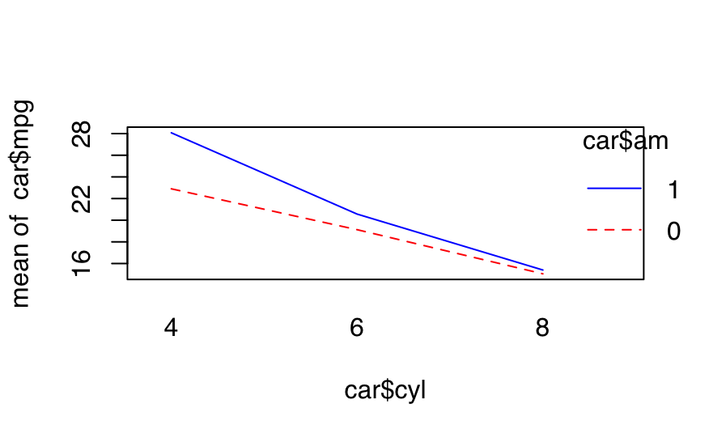

### 5. 상관분석

#### 1. 상관계수에 대한 검정

$$H_0 : \rho = 0$$

- 상관계수

> cor(x,y, method, use)
> - method : 상관계수 방법 (‘pearson’,‘kendall’,‘spearman’)
> - use : na값 처리 방법(‘everything’,‘all.obs’,‘complete.obs’,‘pairwise.complete.obs’)
- 상관계수 행렬 시각화

> pairs(x)

> **corrplot 패키지**

> corrplot(corr, method)
- 상관계수에 대한 검정

> cor.test(x,y, method)

```r
# 가설 검정
cor.test(iris$Petal.Length, iris$Petal.Width)
```

```
    Pearson's product-moment correlation

data:  iris$Petal.Length and iris$Petal.Width
t = 43.387, df = 148, p-value < 2.2e-16
alternative hypothesis: true correlation is not equal to 0
95 percent confidence interval:
 0.9490525 0.9729853
sample estimates:
      cor
0.9628654
```

### 6. 회귀분석

#### 1. 단순/다중 선형회귀분석

- 선형회귀분석

> lm(formula, data)
- 선형회귀모형 진단

> plot(x, which)
> - x : 선형회귀분석 모형
> - which : 그래프 종류

>   1,2 - 오차의 정규성

>   3 - 오차의 정규성 + 이상치

>   4,5 - 이상치
- 예측

> predict(object, newdata)

```r
# 예측
predict.lm(Price_lm, test)
```

```
      68       39        1       34       87
21.84678  5.28642 20.33244 11.47548 21.54311
```

#### 2. 최적회귀방정식

- 전진선택법/후진선택법/단계적선택법

> step(object, scope, direction, k)
> - object : 회귀 모형
> - scope : 모형의 범위( list(upper=…, lower=…) )
> - direction : ‘forward’:전진선택법 / ‘backward’=후진제거법 / ‘stepwise’=단계적선택법
> - k : 모형선택기준 (2=AIC / log()=BIC)

```r
step(lm_step, direction = 'backward')
```

```
Start:  AIC=327.45
Price ~ EngineSize + Horsepower + RPM + Width + Length

             Df Sum of Sq    RSS    AIC
- EngineSize  1      0.05 2764.2 325.45
<none>                    2764.2 327.45
- RPM         1     65.53 2829.7 327.62
- Length      1    285.29 3049.4 334.58
- Width       1    414.88 3179.0 338.45
- Horsepower  1   1332.75 4096.9 362.04

Step:  AIC=325.45
Price ~ Horsepower + RPM + Width + Length

             Df Sum of Sq    RSS    AIC
<none>                    2764.2 325.45
- RPM         1    120.58 2884.8 327.42
- Length      1    314.61 3078.8 333.47
- Width       1    425.45 3189.7 336.76
- Horsepower  1   2897.11 5661.3 390.12

Call:
lm(formula = Price ~ Horsepower + RPM + Width + Length, data = Cars93)

Coefficients:
(Intercept)   Horsepower          RPM
  62.001064     0.174981    -0.002843
      Width       Length
  -1.347265     0.222816
```

#### 3. 다항식 회귀분석

- $$y = \beta_0 + \beta_1(x_1+x_2)+\epsilon$$

> I(x1+x2)
- $$y=\beta_0 + \beta_1 x_1^2+\beta_2 x_2 + \epsilon$$

> I(x1^2)
- $$y=\beta_0 +\beta_1 x + \beta_2 x^2 + \beta_3 x^3 + \cdots + \epsilon$$

> poly(x, degree)

```r
lm(mag~poly(lat, 3), data=quakes)
```

```
Call:
lm(formula = mag ~ poly(lat, 3), data = quakes)

Coefficients:
  (Intercept)  poly(lat, 3)1  poly(lat, 3)2
       4.6204        -0.6424         1.6175
poly(lat, 3)3
       0.3803
```

#### 4. 정규화 회귀분석

- 릿지/라쏘/엘라스틱넷

> **glmnet 패키지**

> glmnet(x,y, alpha , lambda)
> - alpha : 0=릿지 / 1=라쏘 / 0.5=엘라스틱넷
- 교차검증방법을 통한 lambda 설정

> **glmnet 패키지**

> cv.glmnet(x,y alpha)

```r
# 최적의 lambda
(best_lambda <- cv.ridge$lambda.min)
```

```
[1] 0.06048311
```

#### 5. 곡선 데이터

- 곡선 데이터 적합

> **MASS 패키지**

> boxcox(object)
- 로그변환
1. log(y) = x
2. y = log(x)
3. log(y) = log(x)

```r
lambda
```

```
[1] -1.434343
```

#### 6. 일반화 가법모형

$$\hat{y_i}=\hat{\beta_0}+\sum^p_{j=1}f_i(x_{ij}+\hat{\epsilon_i})$$

> **mgcv 패키지**

> gam(formula)
> - formula : y~s(x) (s:분리해서 사용할 예측자)

```r
library(mgcv)

library(MASS) # for data
data("mcycle")

# 일반화 가법모형
gam_model <- gam(accel ~ s(times), data=mcycle)
summary(gam_model)
```

```
Family: gaussian
Link function: identity

Formula:
accel ~ s(times)

Parametric coefficients:
            Estimate Std. Error t value Pr(>|t|)
(Intercept)  -25.546      1.951   -13.1   <2e-16 ***
---
Signif. codes:  0 ‘***’ 0.001 ‘**’ 0.01 ‘*’ 0.05 ‘.’ 0.1 ‘ ’ 1

Approximate significance of smooth terms:
           edf Ref.df     F p-value
s(times) 8.693  8.972 53.52  <2e-16 ***
---
Signif. codes:  0 ‘***’ 0.001 ‘**’ 0.01 ‘*’ 0.05 ‘.’ 0.1 ‘ ’ 1

R-sq.(adj) =  0.783   Deviance explained = 79.8%
GCV = 545.78  Scale est. = 506       n = 133
```

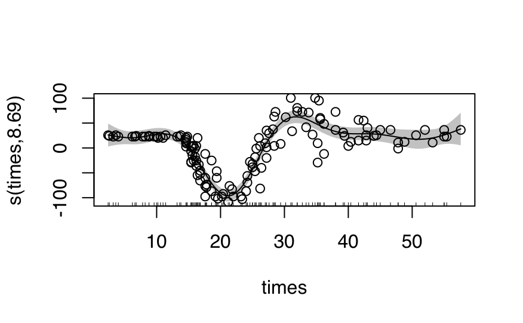

```r
# 시각화
plot(gam_model,residuals = T,pch=1,seWithMean = T,shade=T)
```